# Module 11: Solutions to Recommended Exercises

TMA4268 Statistical Learning V2024

Daesoo Lee, Kenneth Aase, Stefanie Muff, Sara Martino

Department of Mathematical Sciences, NTNU

April 18, 2024

## Problem 1

### a)

It is a 4-4-4-3 feedforward neural network with an extra bias node in both the input and the two hidden layers. It can be written in the following form

$$y_c({\bf x})=\phi_o(\beta_{0c}+\sum_{m=1}^4 \beta_{mc}z_{m})=\phi_o(\beta_{0c}+\sum_{m=1}^4 \beta_{mc}\phi_{h*}(\gamma_{0m}+\sum_{l=1}^4 \gamma_{lm}\phi_h(\alpha_{0l}+\sum_{j=1}^4 \alpha_{jl}x_{j}))).$$

### b)

It is not clear wheter the network has 3 input nodes, or 2 input nodes plus one bias node (both would lead to the same representation). The hidden layer has 4 nodes, but no bias node, and the output layer consists of two nodes. This can be used for regression with two responses. If we have a classifiation problem with two classes then we usually use only one output node, but is is possible to use softmax activation for two classes, but that is very uncommon. Remember that for a binary outcome, we would usually only use one output node that encodes for the probability to be in one of the two classes.

### c)

When the hidden layer has a linear activation the model is only linear in the original covariates, so adding the extra hidden layer will not add non-linearity to the model. The feedforward model may find latent structure in the data in the hidden layer. In general, however, we would then recommend to directly use logistic regression, because you then end up with a model that is easier to interpret.

### d)

This is possible because the neural network is fitted using iterative methods. But, there is not one unique solutions here, and the network will benefit greatly by adding some sort of regulariztion, like weight decay and early stopping.

## Problem 2

### a)

This is a feedforward network with 10 input nodes plus a bias node, a hidden layer with 5 nodes plus a bias node, and a single node in the output layer. The hidden layer has a ReLU activiation function, whereas the output layer has a linear activation function.

The number of the estimated parameters are $(10+1)*5+(5+1)=61$.

### b)

Feedforward network with two hidden layers. Input layer has 4 nodes and no bias term, the first hidden layer has 10 nodes and ReLU activation and a bias node, the second hidden layer has 5 nodes plus a bias node and ReLU activiation. One node in output layer with sigmoid activiation.

The number of estimated parameters are $4*10+(10+1)*5+(5+1)=101$.

### c)

In module 7 we had an additive model of non-linear function, and interactions would be added manually (i.e., explicitly). Each coefficient estimated would be rather easy to interpret. For neural nets we know that with one hidden layer and squashing type activation we can fit any function (regression), but may need many nodes - and then the interpretation might not be so easy. Interactions are automatically handled with the non-linear function of sums.

## Problem 3

##### 1. Load and preprocess data

```r
# load
boston_housing <- dataset_boston_housing()
x_train <- boston_housing$train$x
y_train <- boston_housing$train$y
x_test <- boston_housing$test$x
y_test <- boston_housing$test$y

# preprocess
mean <- apply(x_train, 2, mean)
std <- apply(x_train, 2, sd)
x_train <- scale(x_train, center = mean, scale = std)
x_test <- scale(x_test, center = mean, scale = std)
```

### a)

##### 2. Define the model

```r
model_r <- keras_model_sequential() %>%
  layer_dense(units = 64, activation = "relu", input_shape = 13) %>%
  layer_dense(units = 32, activation = "relu") %>%
  layer_dense(units = 1)

summary(model_r)
```

```
## Model: "sequential"
## ________________________________________________________________________________
##  Layer (type)                       Output Shape                    Param #
## ================================================================================
##  dense_2 (Dense)                    (None, 64)                      896
##  dense_1 (Dense)                    (None, 32)                      2080
##  dense (Dense)                      (None, 1)                       33
## ================================================================================
## Total params: 3009 (11.75 KB)
## Trainable params: 3009 (11.75 KB)
## Non-trainable params: 0 (0.00 Byte)
## ________________________________________________________________________________
```

##### 3. Compile

```r
model_r %>% compile(
  loss = "mean_squared_error",
  optimizer = optimizer_adam(learning_rate = 0.001),  # adam is the most common optimizer for its robustness.
  metrics = c("mean_absolute_error")
)
```

##### 4. Train the model

```r
history <- model_r %>% fit(
  x_train, y_train,
  epochs = 100,
  batch_size = 64,
  validation_data = list(x_test, y_test)
)
```

```
## 7/7 - 0s - loss: 588.8146 - mean_absolute_error: 22.4350 - val_loss: 600.7808 - val_mean_absolute_error: 22.7686 - 442ms/epoch - 63ms/step
## 7/7 - 0s - loss: 562.4655 - mean_absolute_error: 21.8833 - val_loss: 575.5486 - val_mean_absolute_error: 22.2299 - 32ms/epoch - 5ms/step
## 7/7 - 0s - loss: 538.7452 - mean_absolute_error: 21.3495 - val_loss: 550.0892 - val_mean_absolute_error: 21.6780 - 31ms/epoch - 4ms/step
## 7/7 - 0s - loss: 513.8727 - mean_absolute_error: 20.7908 - val_loss: 522.4363 - val_mean_absolute_error: 21.0651 - 27ms/epoch - 4ms/step
## 7/7 - 0s - loss: 486.4429 - mean_absolute_error: 20.1601 - val_loss: 490.9171 - val_mean_absolute_error: 20.3519 - 24ms/epoch - 3ms/step
## 7/7 - 0s - loss: 454.7205 - mean_absolute_error: 19.4180 - val_loss: 455.5644 - val_mean_absolute_error: 19.5223 - 16ms/epoch - 2ms/step
## 7/7 - 0s - loss: 418.5997 - mean_absolute_error: 18.5449 - val_loss: 414.5720 - val_mean_absolute_error: 18.5186 - 36ms/epoch - 5ms/step
## 7/7 - 0s - loss: 377.4985 - mean_absolute_error: 17.4979 - val_loss: 368.2817 - val_mean_absolute_error: 17.2997 - 16ms/epoch - 2ms/step
## 7/7 - 0s - loss: 332.4651 - mean_absolute_error: 16.2540 - val_loss: 318.9785 - val_mean_absolute_error: 15.8773 - 37ms/epoch - 5ms/step
## 7/7 - 0s - loss: 283.8422 - mean_absolute_error: 14.7981 - val_loss: 268.5338 - val_mean_absolute_error: 14.2879 - 12ms/epoch - 2ms/step
## 7/7 - 0s - loss: 236.8352 - mean_absolute_error: 13.1943 - val_loss: 219.9462 - val_mean_absolute_error: 12.7092 - 38ms/epoch - 5ms/step
## 7/7 - 0s - loss: 190.9976 - mean_absolute_error: 11.4751 - val_loss: 176.9172 - val_mean_absolute_error: 11.3244 - 25ms/epoch - 4ms/step
## 7/7 - 0s - loss: 152.4016 - mean_absolute_error: 9.9247 - val_loss: 141.9824 - val_mean_absolute_error: 10.0159 - 18ms/epoch - 3ms/step
## 7/7 - 0s - loss: 122.2198 - mean_absolute_error: 8.7324 - val_loss: 117.0560 - val_mean_absolute_error: 8.8932 - 33ms/epoch - 5ms/step
## 7/7 - 0s - loss: 101.8295 - mean_absolute_error: 7.9201 - val_loss: 99.7786 - val_mean_absolute_error: 8.0526 - 24ms/epoch - 3ms/step
## 7/7 - 0s - loss: 86.7803 - mean_absolute_error: 7.2933 - val_loss: 87.6060 - val_mean_absolute_error: 7.4719 - 24ms/epoch - 3ms/step
## 7/7 - 0s - loss: 76.2576 - mean_absolute_error: 6.7955 - val_loss: 77.1771 - val_mean_absolute_error: 7.0402 - 16ms/epoch - 2ms/step
## 7/7 - 0s - loss: 66.4616 - mean_absolute_error: 6.2963 - val_loss: 68.4410 - val_mean_absolute_error: 6.6572 - 33ms/epoch - 5ms/step
## 7/7 - 0s - loss: 58.3273 - mean_absolute_error: 5.8610 - val_loss: 60.7385 - val_mean_absolute_error: 6.3005 - 16ms/epoch - 2ms/step
## 7/7 - 0s - loss: 51.1789 - mean_absolute_error: 5.4465 - val_loss: 54.5982 - val_mean_absolute_error: 5.9863 - 38ms/epoch - 5ms/step
## 7/7 - 0s - loss: 45.1646 - mean_absolute_error: 5.0863 - val_loss: 49.6512 - val_mean_absolute_error: 5.6833 - 25ms/epoch - 4ms/step
## 7/7 - 0s - loss: 40.6299 - mean_absolute_error: 4.7836 - val_loss: 45.6011 - val_mean_absolute_error: 5.4225 - 25ms/epoch - 4ms/step
## 7/7 - 0s - loss: 36.7330 - mean_absolute_error: 4.5047 - val_loss: 42.3258 - val_mean_absolute_error: 5.2152 - 24ms/epoch - 3ms/step
## 7/7 - 0s - loss: 33.6027 - mean_absolute_error: 4.2877 - val_loss: 39.6411 - val_mean_absolute_error: 5.0240 - 24ms/epoch - 3ms/step
## 7/7 - 0s - loss: 31.1272 - mean_absolute_error: 4.0993 - val_loss: 37.6180 - val_mean_absolute_error: 4.8659 - 24ms/epoch - 3ms/step
## 7/7 - 0s - loss: 29.2291 - mean_absolute_error: 3.9479 - val_loss: 35.9245 - val_mean_absolute_error: 4.7453 - 23ms/epoch - 3ms/step
## 7/7 - 0s - loss: 27.6517 - mean_absolute_error: 3.8215 - val_loss: 34.6220 - val_mean_absolute_error: 4.6587 - 16ms/epoch - 2ms/step
## 7/7 - 0s - loss: 26.4440 - mean_absolute_error: 3.7257 - val_loss: 33.7238 - val_mean_absolute_error: 4.5921 - 31ms/epoch - 4ms/step
## 7/7 - 0s - loss: 25.4266 - mean_absolute_error: 3.6499 - val_loss: 32.6829 - val_mean_absolute_error: 4.5154 - 31ms/epoch - 4ms/step
## 7/7 - 0s - loss: 24.5601 - mean_absolute_error: 3.5686 - val_loss: 31.8658 - val_mean_absolute_error: 4.4468 - 26ms/epoch - 4ms/step
## 7/7 - 0s - loss: 23.8271 - mean_absolute_error: 3.5134 - val_loss: 31.3293 - val_mean_absolute_error: 4.4016 - 25ms/epoch - 4ms/step
## 7/7 - 0s - loss: 23.2459 - mean_absolute_error: 3.4712 - val_loss: 30.5856 - val_mean_absolute_error: 4.3393 - 21ms/epoch - 3ms/step
## 7/7 - 0s - loss: 22.6204 - mean_absolute_error: 3.4241 - val_loss: 30.1295 - val_mean_absolute_error: 4.2942 - 16ms/epoch - 2ms/step
## 7/7 - 0s - loss: 22.0615 - mean_absolute_error: 3.3799 - val_loss: 29.6104 - val_mean_absolute_error: 4.2387 - 39ms/epoch - 6ms/step
## 7/7 - 0s - loss: 21.5884 - mean_absolute_error: 3.3418 - val_loss: 29.2140 - val_mean_absolute_error: 4.2035 - 12ms/epoch - 2ms/step
## 7/7 - 0s - loss: 21.0804 - mean_absolute_error: 3.3036 - val_loss: 28.8590 - val_mean_absolute_error: 4.1681 - 31ms/epoch - 4ms/step
## 7/7 - 0s - loss: 20.6269 - mean_absolute_error: 3.2752 - val_loss: 28.6040 - val_mean_absolute_error: 4.1350 - 31ms/epoch - 4ms/step
## 7/7 - 0s - loss: 20.2079 - mean_absolute_error: 3.2430 - val_loss: 28.2543 - val_mean_absolute_error: 4.0945 - 19ms/epoch - 3ms/step
## 7/7 - 0s - loss: 19.8140 - mean_absolute_error: 3.2110 - val_loss: 28.0663 - val_mean_absolute_error: 4.0707 - 33ms/epoch - 5ms/step
## 7/7 - 0s - loss: 19.4222 - mean_absolute_error: 3.1827 - val_loss: 27.9397 - val_mean_absolute_error: 4.0480 - 25ms/epoch - 4ms/step
```

[output cut: 45 more lines]

```
## 7/7 - 0s - loss: 10.8396 - mean_absolute_error: 2.3161 - val_loss: 23.8284 - val_mean_absolute_error: 3.3257 - 31ms/epoch - 4ms/step
## 7/7 - 0s - loss: 10.8293 - mean_absolute_error: 2.3002 - val_loss: 23.6856 - val_mean_absolute_error: 3.3081 - 31ms/epoch - 4ms/step
## 7/7 - 0s - loss: 10.7026 - mean_absolute_error: 2.2853 - val_loss: 23.7221 - val_mean_absolute_error: 3.3004 - 22ms/epoch - 3ms/step
## 7/7 - 0s - loss: 10.5967 - mean_absolute_error: 2.2818 - val_loss: 23.9509 - val_mean_absolute_error: 3.3058 - 31ms/epoch - 4ms/step
## 7/7 - 0s - loss: 10.5460 - mean_absolute_error: 2.2866 - val_loss: 23.9258 - val_mean_absolute_error: 3.3019 - 16ms/epoch - 2ms/step
## 7/7 - 0s - loss: 10.4704 - mean_absolute_error: 2.2761 - val_loss: 23.6191 - val_mean_absolute_error: 3.2792 - 31ms/epoch - 4ms/step
## 7/7 - 0s - loss: 10.4152 - mean_absolute_error: 2.2632 - val_loss: 23.4898 - val_mean_absolute_error: 3.2664 - 23ms/epoch - 3ms/step
## 7/7 - 0s - loss: 10.3619 - mean_absolute_error: 2.2601 - val_loss: 23.6631 - val_mean_absolute_error: 3.2797 - 31ms/epoch - 4ms/step
## 7/7 - 0s - loss: 10.2906 - mean_absolute_error: 2.2488 - val_loss: 23.3186 - val_mean_absolute_error: 3.2528 - 16ms/epoch - 2ms/step
## 7/7 - 0s - loss: 10.2548 - mean_absolute_error: 2.2435 - val_loss: 23.1621 - val_mean_absolute_error: 3.2368 - 31ms/epoch - 4ms/step
## 7/7 - 0s - loss: 10.1649 - mean_absolute_error: 2.2386 - val_loss: 23.4073 - val_mean_absolute_error: 3.2473 - 20ms/epoch - 3ms/step
## 7/7 - 0s - loss: 10.1111 - mean_absolute_error: 2.2363 - val_loss: 23.6433 - val_mean_absolute_error: 3.2552 - 35ms/epoch - 5ms/step
## 7/7 - 0s - loss: 10.0590 - mean_absolute_error: 2.2302 - val_loss: 23.5000 - val_mean_absolute_error: 3.2456 - 35ms/epoch - 5ms/step
## 7/7 - 0s - loss: 10.0141 - mean_absolute_error: 2.2269 - val_loss: 23.5366 - val_mean_absolute_error: 3.2468 - 28ms/epoch - 4ms/step
## 7/7 - 0s - loss: 9.9575 - mean_absolute_error: 2.2182 - val_loss: 23.3426 - val_mean_absolute_error: 3.2323 - 27ms/epoch - 4ms/step
```

##### 5. Test

```r
scores <- model_r %>% evaluate(x_test, y_test, verbose = 0)

cat("Test loss (MSE):", scores[[1]], "\n",
    "Test mean absolute error (MAE):", scores[[2]], "\n")
```

```
## Test loss (MSE): 23.34256
##  Test mean absolute error (MAE): 3.232276
```

##### Plot training history

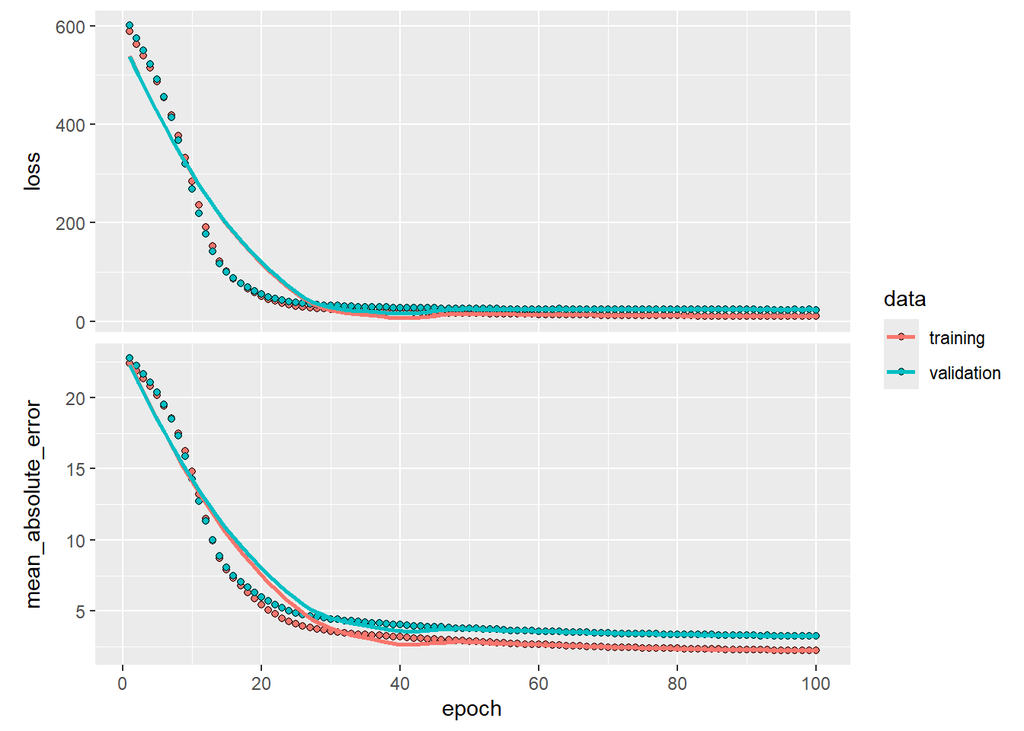

```r
plot(history)
```

```r
predictions <- model_r %>% predict(x_test)
```

```
## 4/4 - 0s - 46ms/epoch - 12ms/step
```

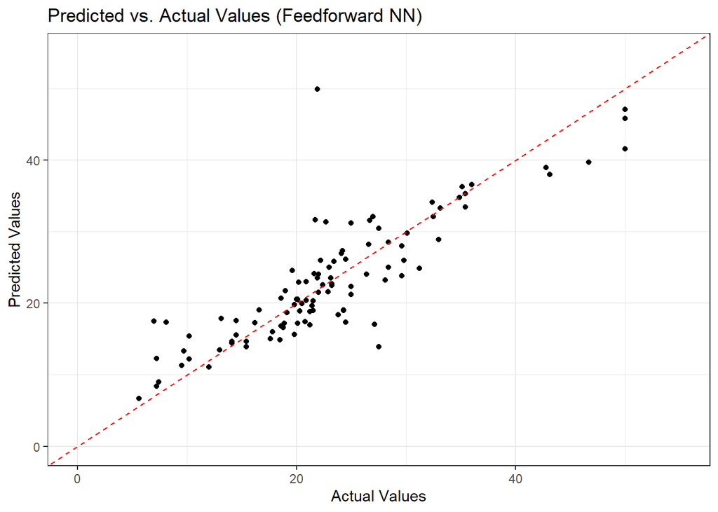

```r
plot_df <- data.frame(Predicted = predictions, Actual = y_test)
ggplot(plot_df, aes(x = Actual, y = Predicted)) +
  geom_point() +
  geom_abline(slope = 1, intercept = 0, color = "red", linetype = "dashed") +
  theme_bw() +
  xlab("Actual Values") +
  ylab("Predicted Values") +
  ggtitle("Predicted vs. Actual Values (Feedforward NN)") +
  xlim(0, 55) +
  ylim(0, 55)
```

### b)

##### Comparison to a Linear Regression Model

```r
# Fit a linear regression model
linear_model <- lm(y_train ~ ., data = as.data.frame(cbind(x_train, y_train)))

# Make predictions on the test set
predictions <- predict(linear_model, as.data.frame(x_test))

# Calculate the mean squared error and mean absolute error
mse <- mean((y_test - predictions)^2)
mae <- mean(abs(y_test - predictions))

cat("=== [Feedforward Neural Network] === \n", "Test loss (MSE):", scores[[1]],
    "\n",
    "Test mean absolute error (MAE):", scores[[2]],
    "\n",
    "==================================== \n\n",
    "=== [Linear Regression] === \n",
    "Test loss (MSE):", mse, "\n",
    "Test mean absolute error (MAE):", mae, "\n",
    "===========================\n\n")
```

```
## === [Feedforward Neural Network] ===
##  Test loss (MSE): 23.34256
##  Test mean absolute error (MAE): 3.232276
##  ====================================
##
##  === [Linear Regression] ===
##  Test loss (MSE): 23.1956
##  Test mean absolute error (MAE): 3.464186
##  ===========================
```

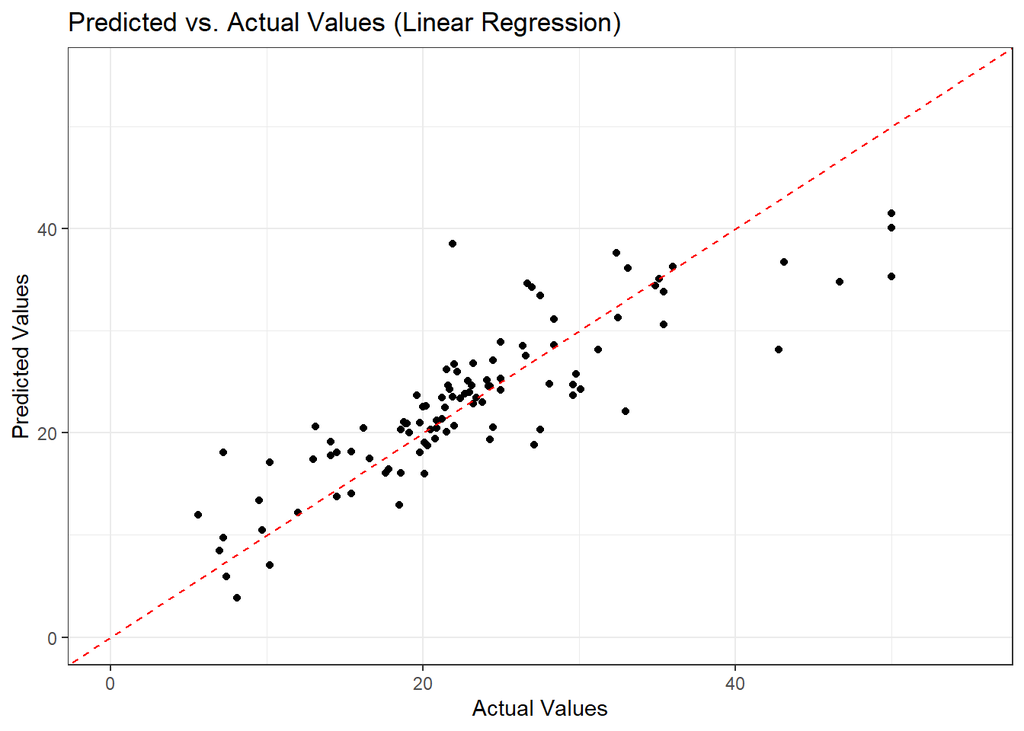

```r
plot_df <- data.frame(Predicted = predictions, Actual = y_test)
ggplot(plot_df, aes(x = Actual, y = Predicted)) +
  geom_point() +
  geom_abline(slope = 1, intercept = 0, color = "red", linetype = "dashed") +
  theme_bw() +
  xlab("Actual Values") +
  ylab("Predicted Values") +
  ggtitle("Predicted vs. Actual Values (Linear Regression)") +
  xlim(0, 55) +
  ylim(0, 55)
```

### c)

```r
keras::k_clear_session()
```

## Problem 4: Convolutional Neural Network (CNN)

### Problem 4.1: Image Classification with CNN

##### 1. Load and preprocess data

```r
cifar10 <- dataset_cifar10()
x_train <- cifar10$train$x / 255
y_train <- to_categorical(cifar10$train$y, num_classes = 10)
x_test <- cifar10$test$x / 255
y_test <- to_categorical(cifar10$test$y, num_classes = 10)
```

### a)

##### 2. Define the model

```r
model_c <- keras_model_sequential() %>%
  layer_conv_2d(filters = 32, kernel_size = c(3, 3), activation = "relu", input_shape = c(32, 32, 3)) %>%
  layer_max_pooling_2d(pool_size = c(2, 2)) %>%
  layer_conv_2d(filters = 64, kernel_size = c(3, 3), activation = "relu") %>%
  layer_max_pooling_2d(pool_size = c(2, 2)) %>%
  layer_flatten() %>%
  layer_dense(units = 64, activation = "relu") %>%
  layer_dense(units = 10, activation = "softmax")

summary(model_c)
```

```
## Model: "sequential"
## ________________________________________________________________________________
##  Layer (type)                       Output Shape                    Param #
## ================================================================================
##  conv2d_1 (Conv2D)                  (None, 30, 30, 32)              896
##  max_pooling2d_1 (MaxPooling2D)     (None, 15, 15, 32)              0
##  conv2d (Conv2D)                    (None, 13, 13, 64)              18496
##  max_pooling2d (MaxPooling2D)       (None, 6, 6, 64)                0
##  flatten (Flatten)                  (None, 2304)                    0
##  dense_1 (Dense)                    (None, 64)                      147520
##  dense (Dense)                      (None, 10)                      650
## ================================================================================
## Total params: 167562 (654.54 KB)
## Trainable params: 167562 (654.54 KB)
## Non-trainable params: 0 (0.00 Byte)
## ________________________________________________________________________________
```

##### 3. Compile

```r
model_c %>% compile(
  loss = "categorical_crossentropy",
  optimizer = optimizer_adam(learning_rate = 0.001),  # adam is the most common optimizer for its robustness.
  metrics = c("accuracy")
)
```

##### 4. Train the model

```r
history <- model_c %>% fit(
  x_train, y_train,
  epochs = 20,
  batch_size = 32,
  validation_data = list(x_test, y_test)
)
```

```
## 1563/1563 - 16s - loss: 1.4141 - accuracy: 0.4938 - val_loss: 1.1463 - val_accuracy: 0.5979 - 16s/epoch - 11ms/step
## 1563/1563 - 16s - loss: 1.0809 - accuracy: 0.6232 - val_loss: 1.0134 - val_accuracy: 0.6453 - 16s/epoch - 10ms/step
## 1563/1563 - 16s - loss: 0.9536 - accuracy: 0.6694 - val_loss: 0.9734 - val_accuracy: 0.6644 - 16s/epoch - 10ms/step
## 1563/1563 - 16s - loss: 0.8707 - accuracy: 0.6984 - val_loss: 0.9085 - val_accuracy: 0.6860 - 16s/epoch - 10ms/step
## 1563/1563 - 16s - loss: 0.7977 - accuracy: 0.7227 - val_loss: 0.9304 - val_accuracy: 0.6805 - 16s/epoch - 10ms/step
## 1563/1563 - 16s - loss: 0.7426 - accuracy: 0.7412 - val_loss: 0.9223 - val_accuracy: 0.6886 - 16s/epoch - 10ms/step
## 1563/1563 - 16s - loss: 0.6893 - accuracy: 0.7611 - val_loss: 0.9189 - val_accuracy: 0.6947 - 16s/epoch - 10ms/step
## 1563/1563 - 16s - loss: 0.6372 - accuracy: 0.7770 - val_loss: 0.9083 - val_accuracy: 0.6960 - 16s/epoch - 10ms/step
## 1563/1563 - 16s - loss: 0.5919 - accuracy: 0.7936 - val_loss: 0.8990 - val_accuracy: 0.7071 - 16s/epoch - 10ms/step
## 1563/1563 - 16s - loss: 0.5452 - accuracy: 0.8090 - val_loss: 1.0376 - val_accuracy: 0.6801 - 16s/epoch - 10ms/step
## 1563/1563 - 16s - loss: 0.5070 - accuracy: 0.8214 - val_loss: 0.9857 - val_accuracy: 0.6936 - 16s/epoch - 10ms/step
## 1563/1563 - 15s - loss: 0.4719 - accuracy: 0.8344 - val_loss: 1.0527 - val_accuracy: 0.6916 - 15s/epoch - 9ms/step
## 1563/1563 - 15s - loss: 0.4386 - accuracy: 0.8448 - val_loss: 1.0474 - val_accuracy: 0.6926 - 15s/epoch - 9ms/step
## 1563/1563 - 15s - loss: 0.4039 - accuracy: 0.8576 - val_loss: 1.1065 - val_accuracy: 0.6905 - 15s/epoch - 9ms/step
## 1563/1563 - 15s - loss: 0.3755 - accuracy: 0.8659 - val_loss: 1.2237 - val_accuracy: 0.6872 - 15s/epoch - 10ms/step
## 1563/1563 - 15s - loss: 0.3451 - accuracy: 0.8758 - val_loss: 1.2155 - val_accuracy: 0.6853 - 15s/epoch - 9ms/step
## 1563/1563 - 15s - loss: 0.3176 - accuracy: 0.8853 - val_loss: 1.3780 - val_accuracy: 0.6813 - 15s/epoch - 9ms/step
## 1563/1563 - 15s - loss: 0.2959 - accuracy: 0.8934 - val_loss: 1.3923 - val_accuracy: 0.6876 - 15s/epoch - 9ms/step
## 1563/1563 - 15s - loss: 0.2754 - accuracy: 0.8994 - val_loss: 1.4420 - val_accuracy: 0.6718 - 15s/epoch - 9ms/step
## 1563/1563 - 15s - loss: 0.2540 - accuracy: 0.9087 - val_loss: 1.5640 - val_accuracy: 0.6814 - 15s/epoch - 9ms/step
```

##### 5. Test

```r
scores <- model_c %>% evaluate(x_test, y_test, verbose = 0)

cat("Test loss:", scores[[1]], "\n",
    "Test accuracy:", scores[[2]], "\n")
```

```
## Test loss: 1.564002
##  Test accuracy: 0.6814
```

##### Plot training history

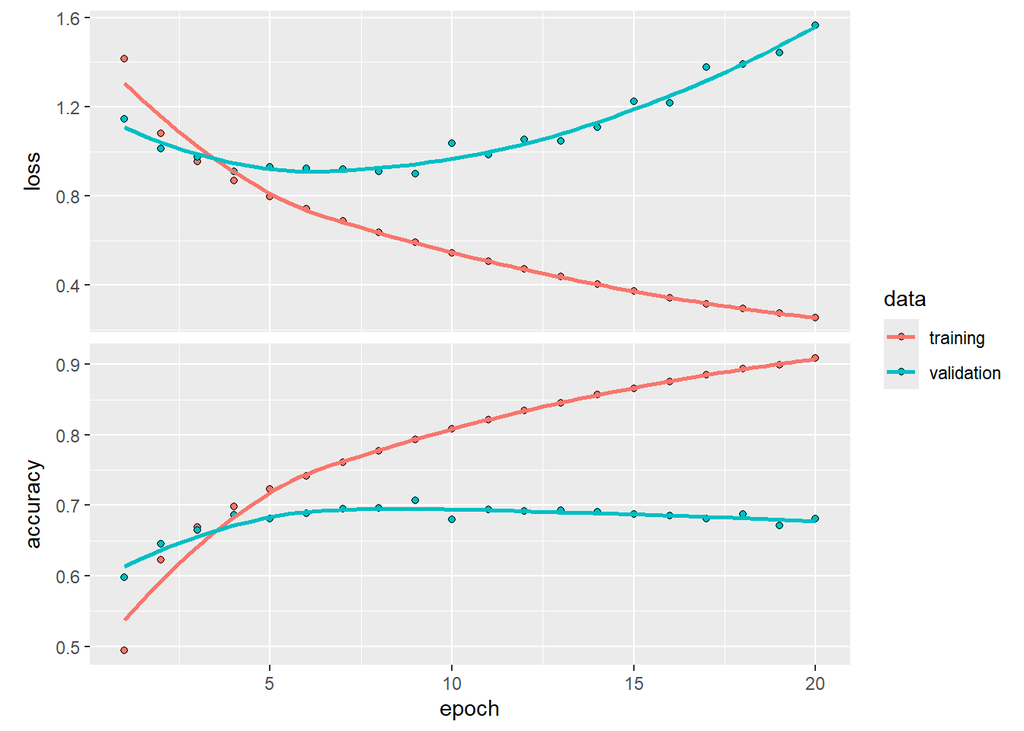

```r
plot(history)
```

##### Additional plot: confusion matrix

```r
library(caret)
predictions <- model_c %>% predict(x_test)%>% k_argmax()
```

```
## 313/313 - 1s - 1s/epoch - 4ms/step
```

```r
y_true <- cifar10$test$y
confusion_matrix <- confusionMatrix(factor(as.vector(predictions)), factor(y_true))
print(confusion_matrix$table)
```

```
##           Reference
## Prediction   0   1   2   3   4   5   6   7   8   9
##          0 781  44  66  23  27  19   8  17  94  45
##          1  11 756   8   9   3   6   8   5  33  65
##          2  56   4 535  59  70  50  49  33  15  10
##          3  22  13  90 517  89 163  96  43  14  13
##          4  21   5 103  67 626  42  60  70   8   6
##          5  15  12  85 198  73 642  58  94  11  13
##          6   4   4  41  30  28  13 683   4  10   2
##          7  10   3  44  48  62  37  13 698  13  11
##          8  49  24   8  15   7   7  10   3 762  21
##          9  31 135  20  34  15  21  15  33  40 814
```

### b)

The exact misclassification rate should be slightly different for each run. A misclassification rate is calculated as (number of misclassified samples / total number of samples).

### Problem 4.2: Improving the test accuarcy with data augmentation techniques

```r
# 1) Load and preprocess data
cifar10 <- dataset_cifar10()
x_train <- cifar10$train$x / 255
y_train <- to_categorical(cifar10$train$y, num_classes = 10)
x_test <- cifar10$test$x / 255
y_test <- to_categorical(cifar10$test$y, num_classes = 10)

# 2) Define the model
model_ca <- keras_model_sequential() %>%
  layer_conv_2d(filters = 32, kernel_size = c(3, 3), activation = "relu", input_shape = c(32, 32, 3)) %>%
  layer_max_pooling_2d(pool_size = c(2, 2)) %>%
  layer_conv_2d(filters = 64, kernel_size = c(3, 3), activation = "relu") %>%
  layer_max_pooling_2d(pool_size = c(2, 2)) %>%
  layer_flatten() %>%
  layer_dense(units = 64, activation = "relu") %>%
  layer_dense(units = 10, activation = "softmax")

# 3) Compile
model_ca %>% compile(
  loss = "categorical_crossentropy",
  optimizer = optimizer_adam(learning_rate = 0.001),
  metrics = c("accuracy")
)

# 4) Data augmentation
datagen <- image_data_generator(
  rotation_range = 10,
  width_shift_range = 0.1,
  height_shift_range = 0.1,
  horizontal_flip = TRUE
)

# Compute the data generator internal statistics
datagen %>% fit_image_data_generator(x_train)

# 5) Train the model with data augmentation
batch_size = 64
train_generator <- flow_images_from_data(x = x_train, y = y_train, generator = datagen, batch_size = batch_size)

history <- model_ca %>% fit_generator(
  generator = train_generator,
  steps_per_epoch = as.integer(nrow(x_train) / batch_size),
  epochs = 20,
  validation_data = list(x_test, y_test)
)
# Test
scores <- model_ca %>% evaluate(x_test, y_test, verbose = 0)

cat("Test loss:", scores[[1]], "\n",
    "Test accuracy:", scores[[2]], "\n")
```

```
## Test loss: 0.9079457
##  Test accuracy: 0.6981
```

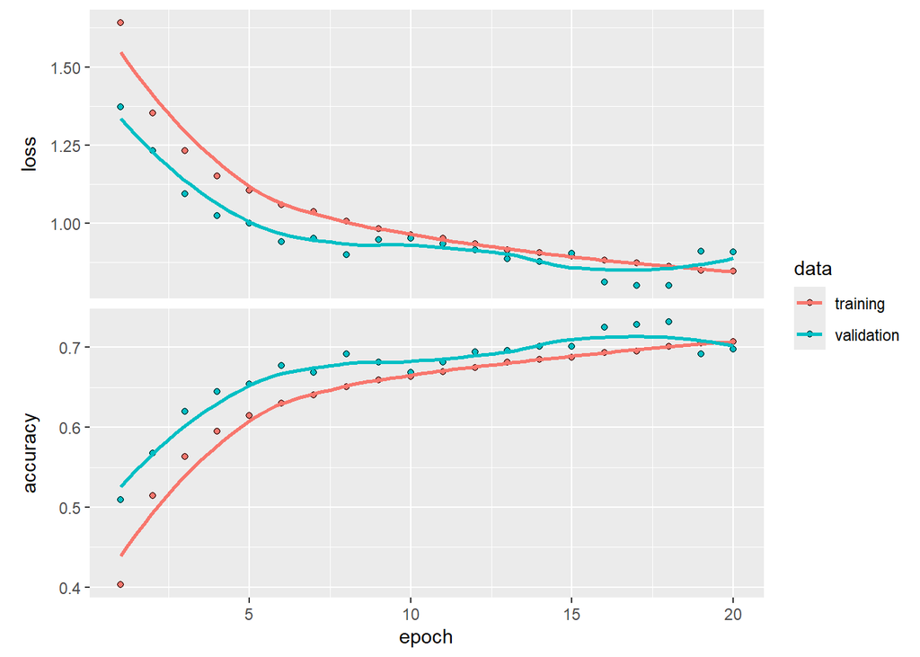

```r
# Plot training history
plot(history)
```

```r
# Additional plot: confusion matrix

predictions <- model_ca %>% predict(x_test)%>% k_argmax()
```

```
## 313/313 - 1s - 1s/epoch - 4ms/step
```

```r
y_true <- cifar10$test$y
confusion_matrix <- confusionMatrix(factor(as.vector(predictions)), factor(y_true))
print(confusion_matrix$table)
```

```
##           Reference
## Prediction   0   1   2   3   4   5   6   7   8   9
##          0 800   8  84  31  31  16  10  19 131  17
##          1  50 873  20  29  10  24  13  14  95  94
##          2  29   2 510  51  37  30  25  14  12   3
##          3   2   1  13 267   8  43  12   8   1   2
##          4  16   2  78  67 631  38  22  26   5   0
##          5   5   0  94 254  34 697  17  56   5   1
##          6   9   7 117 167 107  54 873  16   8   8
##          7  12   2  47  65 123  62  12 812   9   7
##          8  20   2  10  12   3   7   3   3 655   5
##          9  57 103  27  57  16  29  13  32  79 863
```

### a)

1. Increased size of the training dataset: Data augmentation allows for the creation of new training examples from the existing ones, which increases the size of the training dataset. A larger dataset helps in building more robust machine learning models that are less likely to overfit to the training data.
2. Improved generalization: By augmenting the training data, the model is exposed to more diverse examples, which helps it to generalize better to new, unseen data.
3. Increased model performance: Data augmentation can improve the performance of the model by reducing overfitting, especially in cases where the original dataset is small.
4. Cost-effectiveness: Data augmentation can be a cost-effective way of creating new training data, especially when collecting new data is expensive or time-consuming.
5. Reduced bias: Data augmentation can help to reduce bias in the dataset by balancing the class distribution, which is particularly important in cases where the original dataset is imbalanced.
6. Robustness to input variations: Data augmentation can make the model more robust to input variations such as rotation, scaling, and translation, which is useful in applications such as object recognition and natural language processing.

## Problem 5: Univariate Time Series Classification with CNN

##### 1. Load and preprocess data

```r
# load the Wafer dataset
train <- read.delim("dataset/Wafer/Wafer_TRAIN.tsv", header = FALSE, sep = "\t")
test <- read.delim("dataset/Wafer/Wafer_TEST.tsv", header = FALSE, sep = "\t")

# the first column in `train` and `test` contains label info.
# therefore we separate them into `x` and `y`.
x_train <- train[,2:dim(train)[2]]
y_train <- clip(train[,1], 0, 1) #- 1
y_train <- to_categorical(y_train)
x_test <- test[,2:dim(test)[2]]
y_test <- clip(test[,1], 0, 1) #- 1
y_test <- to_categorical(y_test)

# create a channel dimension so that `x` has dimension of (batch, channel, length)
x_train <- array(as.matrix(x_train), dim = c(nrow(x_train), ncol(x_train), 1))
x_test <- array(as.matrix(x_test), dim = c(nrow(x_test), ncol(x_test), 1))

# preprocess
# The provided dataset has already been preprocessed, therefore no need for it.
```

### a)

##### 2. Define the model

```r
# Define the model
model_1dc <- keras_model_sequential() %>%
    layer_conv_1d(filters = 16, kernel_size = 8, activation = "relu", input_shape = c(dim(x_train)[2], 1)) %>%
    layer_max_pooling_1d(pool_size = 2) %>%
    layer_conv_1d(filters = 32, kernel_size = 5, activation = "relu") %>%
    layer_max_pooling_1d(pool_size = 2) %>%
    layer_conv_1d(filters = 64, kernel_size = 3, activation = "relu") %>%
    layer_max_pooling_1d(pool_size = 2) %>%
    layer_flatten() %>%
    layer_dense(units = 2, activation = "softmax")

summary(model_1dc)
```

```
## Model: "sequential_2"
## ________________________________________________________________________________
##  Layer (type)                       Output Shape                    Param #
## ================================================================================
##  conv1d_2 (Conv1D)                  (None, 145, 16)                 144
##  max_pooling1d_2 (MaxPooling1D)     (None, 72, 16)                  0
##  conv1d_1 (Conv1D)                  (None, 68, 32)                  2592
##  max_pooling1d_1 (MaxPooling1D)     (None, 34, 32)                  0
##  conv1d (Conv1D)                    (None, 32, 64)                  6208
##  max_pooling1d (MaxPooling1D)       (None, 16, 64)                  0
##  flatten_2 (Flatten)                (None, 1024)                    0
##  dense_4 (Dense)                    (None, 2)                       2050
## ================================================================================
## Total params: 10994 (42.95 KB)
## Trainable params: 10994 (42.95 KB)
## Non-trainable params: 0 (0.00 Byte)
## ________________________________________________________________________________
```

##### 3. Compile

```r
model_1dc %>% compile(
  loss = "categorical_crossentropy",
  optimizer = optimizer_adam(learning_rate = 0.001),
  metrics = c("accuracy")
)
```

##### 4. Train the model

```r
history <- model_1dc %>% fit(
  x_train, y_train,
  epochs = 100,
  batch_size = 64,
  validation_data = list(x_test, y_test)
)
```

```
## 16/16 - 1s - loss: 0.3766 - accuracy: 0.8960 - val_loss: 0.3434 - val_accuracy: 0.8921 - 801ms/epoch - 50ms/step
## 16/16 - 0s - loss: 0.2649 - accuracy: 0.9030 - val_loss: 0.2439 - val_accuracy: 0.8921 - 267ms/epoch - 17ms/step
## 16/16 - 0s - loss: 0.1816 - accuracy: 0.9180 - val_loss: 0.1576 - val_accuracy: 0.9518 - 233ms/epoch - 15ms/step
## 16/16 - 0s - loss: 0.0951 - accuracy: 0.9740 - val_loss: 0.0694 - val_accuracy: 0.9713 - 235ms/epoch - 15ms/step
## 16/16 - 0s - loss: 0.0373 - accuracy: 0.9890 - val_loss: 0.0321 - val_accuracy: 0.9916 - 232ms/epoch - 14ms/step
## 16/16 - 0s - loss: 0.0173 - accuracy: 0.9950 - val_loss: 0.0242 - val_accuracy: 0.9927 - 254ms/epoch - 16ms/step
## 16/16 - 0s - loss: 0.0123 - accuracy: 0.9950 - val_loss: 0.0212 - val_accuracy: 0.9938 - 232ms/epoch - 14ms/step
## 16/16 - 0s - loss: 0.0098 - accuracy: 0.9980 - val_loss: 0.0200 - val_accuracy: 0.9942 - 238ms/epoch - 15ms/step
## 16/16 - 0s - loss: 0.0084 - accuracy: 0.9980 - val_loss: 0.0197 - val_accuracy: 0.9937 - 232ms/epoch - 14ms/step
## 16/16 - 0s - loss: 0.0076 - accuracy: 0.9980 - val_loss: 0.0185 - val_accuracy: 0.9951 - 232ms/epoch - 14ms/step
## 16/16 - 0s - loss: 0.0053 - accuracy: 0.9990 - val_loss: 0.0178 - val_accuracy: 0.9950 - 223ms/epoch - 14ms/step
## 16/16 - 0s - loss: 0.0045 - accuracy: 0.9990 - val_loss: 0.0172 - val_accuracy: 0.9955 - 247ms/epoch - 15ms/step
## 16/16 - 0s - loss: 0.0040 - accuracy: 0.9990 - val_loss: 0.0168 - val_accuracy: 0.9956 - 232ms/epoch - 14ms/step
## 16/16 - 0s - loss: 0.0035 - accuracy: 0.9990 - val_loss: 0.0164 - val_accuracy: 0.9956 - 223ms/epoch - 14ms/step
## 16/16 - 0s - loss: 0.0030 - accuracy: 1.0000 - val_loss: 0.0166 - val_accuracy: 0.9956 - 247ms/epoch - 15ms/step
## 16/16 - 0s - loss: 0.0032 - accuracy: 0.9990 - val_loss: 0.0165 - val_accuracy: 0.9958 - 247ms/epoch - 15ms/step
## 16/16 - 0s - loss: 0.0022 - accuracy: 1.0000 - val_loss: 0.0164 - val_accuracy: 0.9958 - 238ms/epoch - 15ms/step
## 16/16 - 0s - loss: 0.0022 - accuracy: 0.9990 - val_loss: 0.0168 - val_accuracy: 0.9955 - 247ms/epoch - 15ms/step
## 16/16 - 0s - loss: 0.0021 - accuracy: 1.0000 - val_loss: 0.0164 - val_accuracy: 0.9959 - 223ms/epoch - 14ms/step
## 16/16 - 0s - loss: 0.0013 - accuracy: 1.0000 - val_loss: 0.0166 - val_accuracy: 0.9956 - 247ms/epoch - 15ms/step
## 16/16 - 0s - loss: 0.0013 - accuracy: 1.0000 - val_loss: 0.0166 - val_accuracy: 0.9956 - 238ms/epoch - 15ms/step
## 16/16 - 0s - loss: 9.8278e-04 - accuracy: 1.0000 - val_loss: 0.0166 - val_accuracy: 0.9959 - 232ms/epoch - 14ms/step
## 16/16 - 0s - loss: 9.2371e-04 - accuracy: 1.0000 - val_loss: 0.0167 - val_accuracy: 0.9958 - 232ms/epoch - 14ms/step
## 16/16 - 0s - loss: 7.9650e-04 - accuracy: 1.0000 - val_loss: 0.0169 - val_accuracy: 0.9958 - 238ms/epoch - 15ms/step
## 16/16 - 0s - loss: 7.3206e-04 - accuracy: 1.0000 - val_loss: 0.0170 - val_accuracy: 0.9958 - 232ms/epoch - 14ms/step
## 16/16 - 0s - loss: 7.8925e-04 - accuracy: 1.0000 - val_loss: 0.0173 - val_accuracy: 0.9955 - 247ms/epoch - 15ms/step
## 16/16 - 0s - loss: 7.6681e-04 - accuracy: 1.0000 - val_loss: 0.0173 - val_accuracy: 0.9959 - 238ms/epoch - 15ms/step
## 16/16 - 0s - loss: 6.5852e-04 - accuracy: 1.0000 - val_loss: 0.0176 - val_accuracy: 0.9958 - 232ms/epoch - 14ms/step
## 16/16 - 0s - loss: 4.6982e-04 - accuracy: 1.0000 - val_loss: 0.0174 - val_accuracy: 0.9959 - 247ms/epoch - 15ms/step
## 16/16 - 0s - loss: 4.6049e-04 - accuracy: 1.0000 - val_loss: 0.0176 - val_accuracy: 0.9961 - 238ms/epoch - 15ms/step
## 16/16 - 0s - loss: 4.0983e-04 - accuracy: 1.0000 - val_loss: 0.0178 - val_accuracy: 0.9958 - 247ms/epoch - 15ms/step
## 16/16 - 0s - loss: 3.8659e-04 - accuracy: 1.0000 - val_loss: 0.0179 - val_accuracy: 0.9959 - 238ms/epoch - 15ms/step
## 16/16 - 0s - loss: 3.4073e-04 - accuracy: 1.0000 - val_loss: 0.0180 - val_accuracy: 0.9961 - 247ms/epoch - 15ms/step
## 16/16 - 0s - loss: 3.1494e-04 - accuracy: 1.0000 - val_loss: 0.0181 - val_accuracy: 0.9961 - 254ms/epoch - 16ms/step
## 16/16 - 0s - loss: 2.9588e-04 - accuracy: 1.0000 - val_loss: 0.0184 - val_accuracy: 0.9959 - 247ms/epoch - 15ms/step
## 16/16 - 0s - loss: 2.7069e-04 - accuracy: 1.0000 - val_loss: 0.0183 - val_accuracy: 0.9963 - 238ms/epoch - 15ms/step
## 16/16 - 0s - loss: 2.7806e-04 - accuracy: 1.0000 - val_loss: 0.0185 - val_accuracy: 0.9959 - 247ms/epoch - 15ms/step
## 16/16 - 0s - loss: 2.4464e-04 - accuracy: 1.0000 - val_loss: 0.0186 - val_accuracy: 0.9958 - 232ms/epoch - 14ms/step
## 16/16 - 0s - loss: 2.4441e-04 - accuracy: 1.0000 - val_loss: 0.0186 - val_accuracy: 0.9958 - 238ms/epoch - 15ms/step
## 16/16 - 0s - loss: 2.1473e-04 - accuracy: 1.0000 - val_loss: 0.0188 - val_accuracy: 0.9959 - 232ms/epoch - 14ms/step
```

[output cut: 45 more lines]

```
## 16/16 - 0s - loss: 2.8782e-05 - accuracy: 1.0000 - val_loss: 0.0236 - val_accuracy: 0.9958 - 232ms/epoch - 14ms/step
## 16/16 - 0s - loss: 2.7718e-05 - accuracy: 1.0000 - val_loss: 0.0237 - val_accuracy: 0.9956 - 238ms/epoch - 15ms/step
## 16/16 - 0s - loss: 2.8493e-05 - accuracy: 1.0000 - val_loss: 0.0239 - val_accuracy: 0.9956 - 247ms/epoch - 15ms/step
## 16/16 - 0s - loss: 2.5936e-05 - accuracy: 1.0000 - val_loss: 0.0239 - val_accuracy: 0.9956 - 247ms/epoch - 15ms/step
## 16/16 - 0s - loss: 2.5409e-05 - accuracy: 1.0000 - val_loss: 0.0241 - val_accuracy: 0.9956 - 238ms/epoch - 15ms/step
## 16/16 - 0s - loss: 2.5373e-05 - accuracy: 1.0000 - val_loss: 0.0241 - val_accuracy: 0.9958 - 232ms/epoch - 14ms/step
## 16/16 - 0s - loss: 2.3787e-05 - accuracy: 1.0000 - val_loss: 0.0243 - val_accuracy: 0.9958 - 254ms/epoch - 16ms/step
## 16/16 - 0s - loss: 2.3054e-05 - accuracy: 1.0000 - val_loss: 0.0243 - val_accuracy: 0.9958 - 247ms/epoch - 15ms/step
## 16/16 - 0s - loss: 2.2238e-05 - accuracy: 1.0000 - val_loss: 0.0245 - val_accuracy: 0.9956 - 238ms/epoch - 15ms/step
## 16/16 - 0s - loss: 2.2071e-05 - accuracy: 1.0000 - val_loss: 0.0245 - val_accuracy: 0.9958 - 247ms/epoch - 15ms/step
## 16/16 - 0s - loss: 2.1802e-05 - accuracy: 1.0000 - val_loss: 0.0246 - val_accuracy: 0.9959 - 232ms/epoch - 14ms/step
## 16/16 - 0s - loss: 2.0777e-05 - accuracy: 1.0000 - val_loss: 0.0247 - val_accuracy: 0.9958 - 238ms/epoch - 15ms/step
## 16/16 - 0s - loss: 1.9756e-05 - accuracy: 1.0000 - val_loss: 0.0248 - val_accuracy: 0.9958 - 232ms/epoch - 14ms/step
## 16/16 - 0s - loss: 1.9289e-05 - accuracy: 1.0000 - val_loss: 0.0249 - val_accuracy: 0.9958 - 254ms/epoch - 16ms/step
## 16/16 - 0s - loss: 1.8973e-05 - accuracy: 1.0000 - val_loss: 0.0250 - val_accuracy: 0.9958 - 247ms/epoch - 15ms/step
```

```r
# Test
scores <- model_1dc %>% evaluate(x_test, y_test, verbose = 0)

cat("Test loss:", scores[[1]], "\n",
    "Test accuracy:", scores[[2]], "\n")
```

```
## Test loss: 0.02496975
##  Test accuracy: 0.995782
```

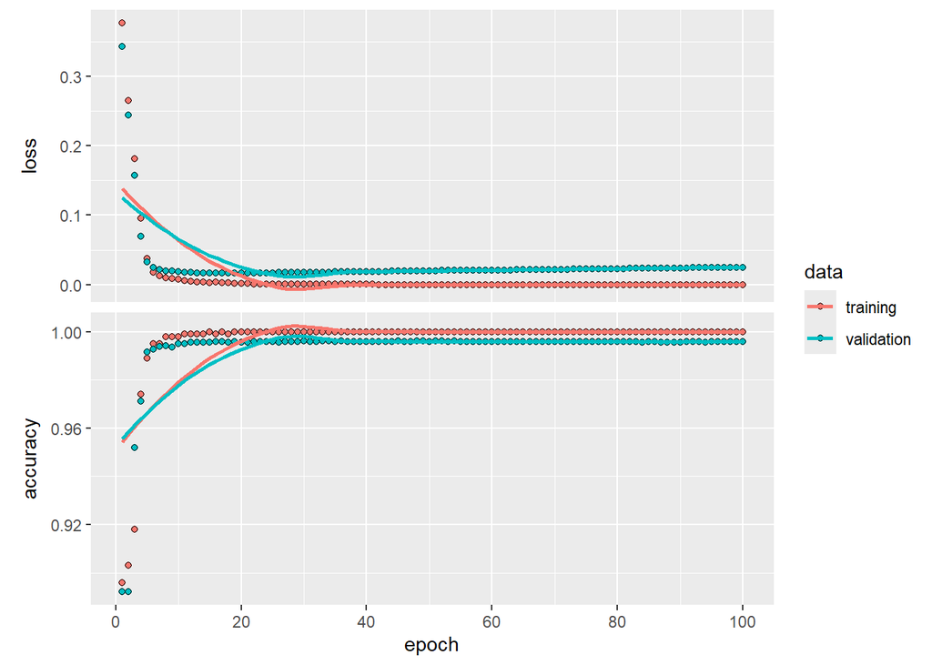

```r
# Plot training history
plot(history)
```

### b)

##### Comparison to a Logistic Regression Model

```r
# dataset
x_train <- train[,2:dim(train)[2]]
y_train <- clip(train[,1], 0, 1)
x_test <- test[,2:dim(test)[2]]
y_test <- clip(test[,1], 0, 1)

# Fit a linear regression model
#linear_model <- lm(y_train ~ ., data = as.data.frame(cbind(x_train, y_train)))
logit_reg <- glm(y_train ~ ., data = as.data.frame(cbind(x_train, y_train)), family = "binomial")

# Make predictions on the test set
predictions <- predict(logit_reg, newdata = x_test, type = "response")
predictions <- as.integer(predictions > 0.5)  # cutoff = 0.5
predictions <- as.factor(predictions)

result <- confusionMatrix(predictions, as.factor(y_test))

cat("=== [1D CNN] === \n", "Test accuracy:", scores[[2]],
    "\n",
    "============================ \n\n",
    "=== [Logistic Regression] === \n",
    "Test accuracy:", result$overall["Accuracy"], "\n",
    "=============================\n\n")
```

```
## === [1D CNN] ===
##  Test accuracy: 0.995782
##  ============================
##
##  === [Logistic Regression] ===
##  Test accuracy: 0.9018494
##  =============================
```